# Презентация по лабораторной работе №14

Дисциплина: операционные системы

Лобанова П. И.

Российский университет дружбы народов, Москва, Россия

09.05.2023

# Информация

## Докладчик

- Лобанова Полина Иннокентьевна
- учащаяся факультета физико-математических и естественных наук
- учащаяся направления “Компьютерные и информационные науки”
- Российский университет дружбы народов
- polla-2004@mail.ru

# Цель работы

Приобретение практических навыков работы с именованными каналами.

# Ход работы

## Задание

Изучите приведённые в тексте программы server.c и client.c. Взяв данные примеры за образец, напишите аналогичные программы, внеся следующие изменения: 1. Работает не 1 клиент, а несколько (например, два). 2. Клиенты передают текущее время с некоторой периодичностью (например, раз в пять секунд). Используйте функцию sleep() для приостановки работы клиента. 3. Сервер работает не бесконечно, а прекращает работу через некоторое время (например, 30 сек). Используйте функцию clock() для определения времени работы сервера.

## Написание файлов

Первое, что нам нужно сделать, это просмотреть исходные файлы и внести свои изменения.

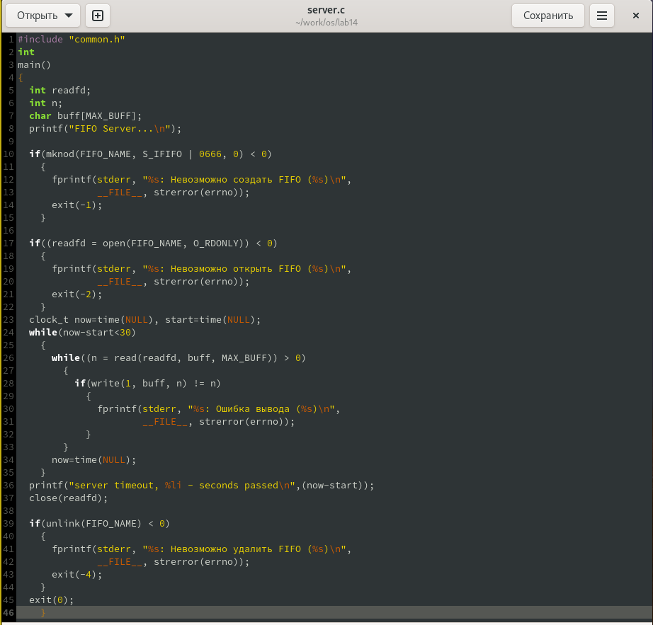

*Содержание файла server.c.*

## Написание файлов

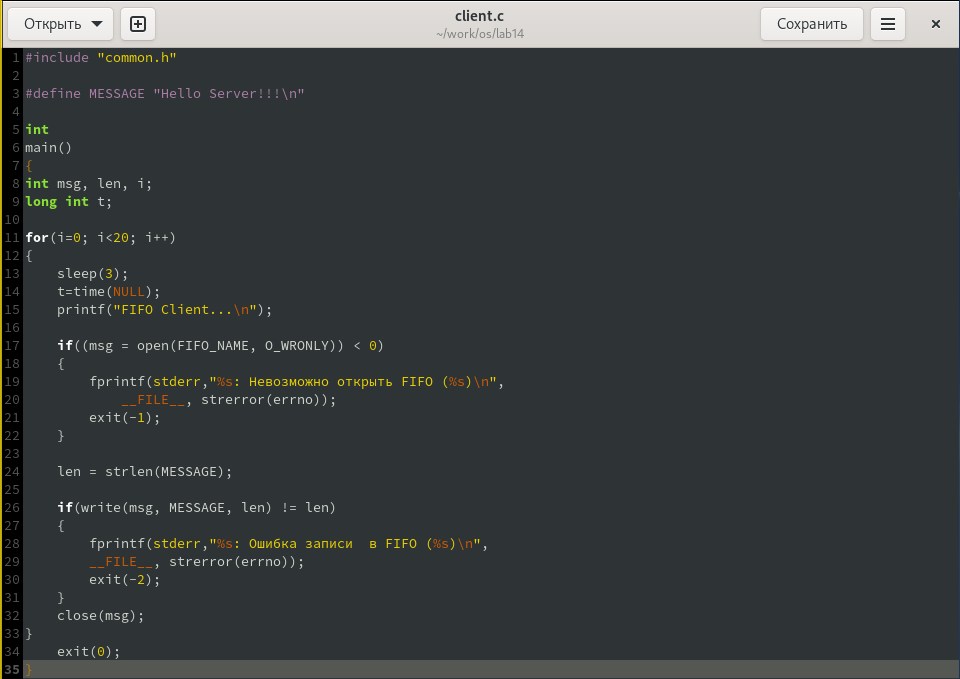

*Содержание файла client.c.*

## Компиляция

Далее необходимо скомпилировать два этих файла, это мы делаем с помощью файла Makefile.

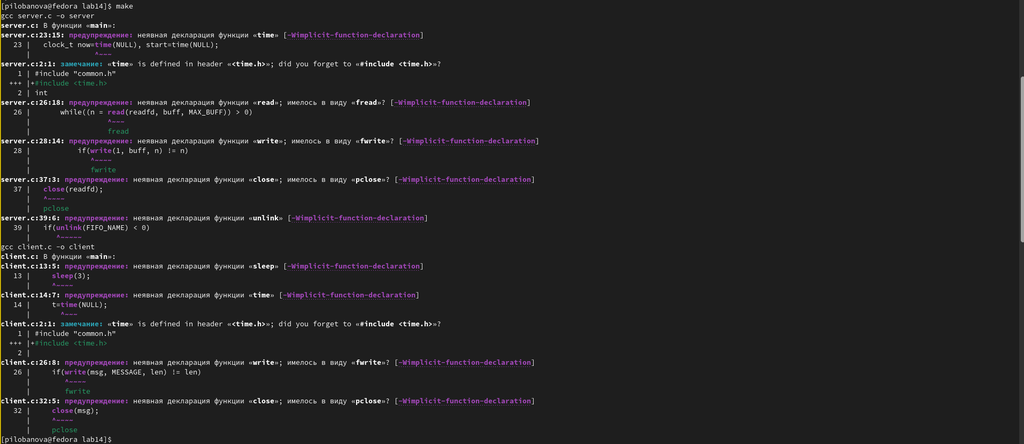

*Компиляция.*

## Результат программы

И последнее, что мы делаем, это запуск самой программы.

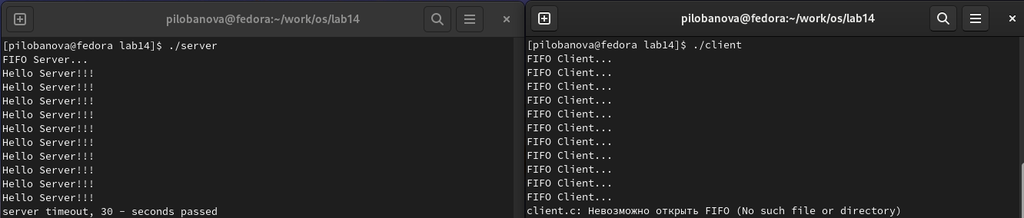

*Результат.*

# Контрольные вопросы

1. В чем ключевое отличие именованных каналов от неименованных?
2. Возможно ли создание неименованного канала из командной строки?
3. Возможно ли создание именованного канала из командной строки?
4. Опишите функцию языка С, создающую неименованный канал.
5. Опишите функцию языка С, создающую именованный канал.
6. Что будет в случае прочтения из fifo меньшего числа байтов, чем находится в канале? Большего числа байтов?
7. Аналогично, что будет в случае записи в fifo меньшего числа байтов, чем позволяет буфер? Большего числа байтов?
8. Могут ли два и более процессов читать или записывать в канал?
9. Опишите функцию write (тип возвращаемого значения, аргументы и логику работы). Что означает 1 (единица) в вызове этой функции в программе server.c (строка 42)?
10. Опишите функцию strerror.

# Вывод

Я приобрела практические навыки работы с именованными каналами.